# Feature Extraction

**In this section we will focus on feature extraction from a single image or a batch of images. For this project our masks (ROI) are already segmented.**

*On average, Pyradiomics extracts ≈1500 features per image, which consist of the 16 shape descriptors and features extracted from original and derived images (LoG with 5 sigma levels, 1 level of Wavelet decomposistions yielding 8 derived images and images derived using Square, Square Root, Logarithm and Exponential filters).*

Detailed description on feature classes and individual features is provided in section [Radiomic Features](https://pyradiomics.readthedocs.io/en/latest/features.html#radiomics-features-label) of the documentation.

This example shows how to use the radiomics package and the feature extractor. The feature extractor handles preprocessing, and then calls the needed featureclasses to calculate the features.

### Setting up imports

First, import some built-in Python modules needed to get our testing data. Second, import the toolbox, only the `featureextractor` is needed, this module handles the interaction with other parts of the toolbox.

```python
# If you edit a module file, Jupyter’s autoreload extension reloads imported modules:
%load_ext autoreload
%autoreload

%matplotlib inline
import matplotlib.pyplot as plt
import six
import os  # needed navigate the system to get the input data
import SimpleITK as sitk
import logging
import csv
import collections
import radiomics
from datetime import datetime
from radiomics import getTestCase
from radiomics import featureextractor, getFeatureClasses
```

### Setting up logging

```python
# Get the PyRadiomics logger (default log-level = INFO)
logger = radiomics.logger
logger.setLevel(logging.DEBUG)  # set level to DEBUG to include debug log messages in log file

# Write out all log entries to a file
handler = logging.FileHandler(filename='test_log.txt', mode='w')
formatter = logging.Formatter('%(levelname)s:%(name)s: %(message)s')
handler.setFormatter(formatter)
logger.addHandler(handler)
```

## Single image

### Setting up data

Test cases can be downloaded to temporary files. This is handled by the `radiomics.getTestCase()` function, which checks if the requested test case is available and if not, downloads it. It returns a tuple with the location of the image and mask of the requested test case, or (None, None) if it fails.

Alternatively, if the data is available somewhere locally, this directory can be passed as a second argument to `radiomics.getTestCase()`. If that directory does not exist or does not contain the testcase, functionality reverts to default and tries to download the test data.

If getting the test case fails, PyRadiomics will log an error explaining the cause.

```python
# repositoryRoot points to the root of the repository. The following line gets that location if this Notebook is run
# from it's default location in \radiomics\thesis-paper\notebooks
repositoryRoot = os.path.abspath(os.path.join(os.getcwd(), ".."))
data_path = os.path.join(repositoryRoot, "data/input-images")
print("Data Path: ", data_path)

imagepath_1, labelpath_1 = getTestCase('brain1', data_path)

if imagepath_1 is None or labelpath_1 is None:  # Something went wrong, in this case PyRadiomics will also log an error
    raise Exception('Error getting testcase!')  # Raise exception to prevent cells below from running in case of "run all"

image_1 = sitk.ReadImage(imagepath_1)
label_1 = sitk.ReadImage(labelpath_1)
```

```
Data Path:  /home/manos/git/radiomics-thesis-paper/data/input-images
```

### Show the image

Using `matplotlib.pyplot` (referenced as `plt`), display the images in grayscale and labels in color.

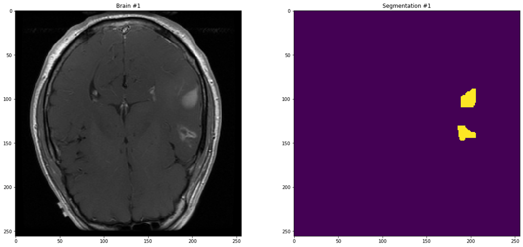

```python
plt.figure(figsize=(20,20))
# First image
plt.subplot(2,2,1)
plt.imshow(sitk.GetArrayFromImage(image_1)[12,:,:], cmap="gray")
plt.title("Brain #1")
plt.subplot(2,2,2)
plt.imshow(sitk.GetArrayFromImage(label_1)[12,:,:])
plt.title("Segmentation #1")

plt.show()
```

### Instantiating the extractor

Now that we have our input, we need to define the parameters and instantiate the extractor. For this there are five possibilities:

**1. Use defaults, don't define custom settings**

```
extractor = featureextractor.RadiomicsFeatureExtractor()
```

**2. Define parameters in a dictionary**

```
# First define the settings
settings = {}
settings['binWidth'] = 20
settings['sigma'] = [1, 2, 3]

# Instantiate the extractor
extractor = featureextractor.RadiomicsFeatureExtractor(**settings)
```

**3. Define parameters in the constructor**

```
extractor = featureextractor.RadiomicsFeatureExtractor(binWidth=20, sigma=[1, 2, 3])
```

**4. Control filters and features after initialisation**

```
extractor.enableImageTypeByName('LoG')

# Disable all feature classes, save firstorder
extractor.disableAllFeatures()
extractor.enableFeatureClassByName('firstorder')

# Specify some additional features in the GLCM feature class
extractor.enableFeaturesByName(glcm=['Autocorrelation', 'Homogeneity1', 'SumSquares'])
```

**5. Use a parameter file**

```
paramsPath = os.path.join('..', 'examples', 'exampleSettings', 'Params.yaml')
extractor = featureextractor.RadiomicsFeatureExtractor(paramsPath)
```

```python
# Get the location of the example settings file
settings_path = os.path.join(repositoryRoot, "settings")
params = os.path.join(settings_path, 'Params.yaml')

# Instantiate the extractor
if os.path.isfile(params):
    extractor = featureextractor.RadiomicsFeatureExtractor(params)
else:  # Parameter file not found, use hardcoded settings instead
    settings = {}
    settings['binWidth'] = 25
    settings['resampledPixelSpacing'] = None  # [3,3,3]
    settings['interpolator'] = sitk.sitkBSpline
    settings['enableCExtensions'] = True

    extractor = featureextractor.RadiomicsFeatureExtractor(**settings)

print('Extraction parameters:')
for setting in extractor.settings.keys():
    print('\t' + setting)

print('\nEnabled filters:')
for image_type in extractor.enabledImagetypes.keys():
    print('\t' + image_type)

print('\nEnabled features:')
for feature in extractor.enabledFeatures.keys():
    print('\t' + feature)
```

```
Extraction parameters:
	minimumROIDimensions
	minimumROISize
	normalize
	normalizeScale
	removeOutliers
	resampledPixelSpacing
	interpolator
	preCrop
	padDistance
	distances
	force2D
	force2Ddimension
	resegmentRange
	label
	additionalInfo
	binWidth
	weightingNorm

Enabled filters:
	Original

Enabled features:
	shape
	firstorder
	glcm
	glrlm
	glszm
	gldm
```

### Extract features

Now that we have our extractor set up with the correct parameters, we can start extracting features:

```python
result = extractor.execute(image_1, label_1)
```

```python
print('Result type:', type(result))  # result is returned in a Python ordered dictionary)
print('')
print('Calculated feature')
for key, value in six.iteritems(result):
    print('\t', key, ':', value)
```

```
Result type: <class 'collections.OrderedDict'>

Calculated feature
	 diagnostics_Versions_PyRadiomics : v3.0.post2+g896682d
	 diagnostics_Versions_Numpy : 1.17.2
	 diagnostics_Versions_SimpleITK : 1.2.4
	 diagnostics_Versions_PyWavelet : 1.0.0
	 diagnostics_Versions_Python : 3.7.4
	 diagnostics_Configuration_Settings : {'minimumROIDimensions': 2, 'minimumROISize': None, 'normalize': False, 'normalizeScale': 1, 'removeOutliers': None, 'resampledPixelSpacing': None, 'interpolator': 'sitkBSpline', 'preCrop': False, 'padDistance': 5, 'distances': [1], 'force2D': False, 'force2Ddi…
	 diagnostics_Configuration_EnabledImageTypes : {'Original': {}}
	 diagnostics_Image-original_Hash : 5c9ce3ca174f0f8324aa4d277e0fef82dc5ac566
	 diagnostics_Image-original_Dimensionality : 3D
	 diagnostics_Image-original_Spacing : (0.7812499999999999, 0.7812499999999999, 6.499999999999998)
	 diagnostics_Image-original_Size : (256, 256, 25)
	 diagnostics_Image-original_Mean : 385.6564080810547
	 diagnostics_Image-original_Minimum : 0.0
	 diagnostics_Image-original_Maximum : 3057.0
	 diagnostics_Mask-original_Hash : 9dc2c3137b31fd872997d92c9a92d5178126d9d3
	 diagnostics_Mask-original_Spacing : (0.7812499999999999, 0.7812499999999999, 6.499999999999998)
	 diagnostics_Mask-original_Size : (256, 256, 25)
	 diagnostics_Mask-original_BoundingBox : (162, 84, 11, 47, 70, 7)
	 diagnostics_Mask-original_VoxelNum : 4137
	 diagnostics_Mask-original_VolumeNum : 2
	 diagnostics_Mask-original_CenterOfMassIndex : (186.98549673676578, 106.3562968334542, 14.38917089678511)
	 diagnostics_Mask-original_CenterOfMass : (46.47304432559825, 16.518518098863908, 15.529610829103234)
	 original_shape_Elongation : 0.5621171627174117
	 original_shape_Flatness : 0.46105975346582595
	 original_shape_LeastAxisLength : 28.584423185376487
	 original_shape_MajorAxisLength : 61.99722046980877
	 original_shape_Maximum2DDiameterColumn : 49.490854979101925
	 original_shape_Maximum2DDiameterRow : 65.88905951721043
	 original_shape_Maximum2DDiameterSlice : 53.59397776919529
	 original_shape_Maximum3DDiameter : 69.60099030590368
	 original_shape_MeshVolume : 16147.51180013021
	 original_shape_MinorAxisLength : 34.84970166685475
	 original_shape_Sphericity : 0.4798234536231475
	 original_shape_SurfaceArea : 6438.821603779402
	 original_shape_SurfaceVolumeRatio : 0.3987500788652454
	 original_shape_VoxelVolume : 16412.658691406243
	 original_firstorder_10Percentile : 632.0
```

[output cut: 70 more lines]

```
	 original_glszm_ZoneVariance : 8.721239097486347
	 original_gldm_DependenceEntropy : 6.885019899269458
	 original_gldm_DependenceNonUniformity : 936.6601401982113
	 original_gldm_DependenceNonUniformityNormalized : 0.22641047623838803
	 original_gldm_DependenceVariance : 2.1619872286911965
	 original_gldm_GrayLevelNonUniformity : 186.8143582306019
	 original_gldm_GrayLevelVariance : 39.19271419906397
	 original_gldm_HighGrayLevelEmphasis : 280.4065748126662
	 original_gldm_LargeDependenceEmphasis : 8.661590524534686
	 original_gldm_LargeDependenceHighGrayLevelEmphasis : 2335.0519700265895
	 original_gldm_LargeDependenceLowGrayLevelEmphasis : 0.07650590736710827
	 original_gldm_LowGrayLevelEmphasis : 0.00860027409479837
	 original_gldm_SmallDependenceEmphasis : 0.37960167130711403
	 original_gldm_SmallDependenceHighGrayLevelEmphasis : 110.30563945728201
	 original_gldm_SmallDependenceLowGrayLevelEmphasis : 0.0035453562622343696
```

## Batch of images

### Setting up data

Here we define some paths for the necessary files.

```python
# repositoryRoot points to the root of the repository. The following line gets that location if this Notebook is run
# from it's default location in \radiomics\thesis-paper\notebooks
repositoryRoot = os.path.abspath(os.path.join(os.getcwd(), ".."))
data_path = os.path.join(repositoryRoot, "data")
settings_path = os.path.join(repositoryRoot, "settings")

inputCSV = os.path.join(settings_path, 'batch_test_cases.csv')
params = os.path.join(settings_path, 'Params.yaml')
```

Read a CSV file that contains paths for the images that we need to process.

*The input file for batch processing is a CSV file where the first row contains headers and each subsequent row represents one combination of an image and a segmentation and contains at least 2 elements: 1) path/to/image, 2) path/to/mask. The headers specify the column names and must be “Image” and “Mask” for image and mask location, respectively (capital sensitive). Additional columns may also be specified, all columns are copied to the output in the same order (with calculated features appended after last column).*

Read more on the [documentation](https://pyradiomics.readthedocs.io/en/latest/usage.html#batch-mode)

```python
logger.info('Loading CSV')
flists = []
try:
    with open(inputCSV, 'r') as inFile:
        cr = csv.DictReader(inFile, lineterminator='\n')
        flists = [row for row in cr]
except Exception:
    logger.error('CSV READ FAILED', exc_info=True)

logger.info('Loading Done')
logger.info('Patients: %d', len(flists))
```

### Instantiating the extractor

Instantiate the features extractor using the settings (Params.yaml) file, if the file doesn't exists use some other settings.

```python
if os.path.isfile(params):
    extractor = featureextractor.RadiomicsFeatureExtractor(params)
else:  # Parameter file not found, use hardcoded settings instead
    settings = {}
    settings['binWidth'] = 25
    settings['resampledPixelSpacing'] = None  # [3,3,3]
    settings['interpolator'] = sitk.sitkBSpline
    settings['enableCExtensions'] = True

    extractor = featureextractor.RadiomicsFeatureExtractor(**settings)
    # extractor.enableInputImages(wavelet= {'level': 2})

logger.info('Enabled input images types: %s', extractor.enabledImagetypes)
logger.info('Enabled features: %s', extractor.enabledFeatures)
logger.info('Current settings: %s', extractor.settings)
```

### Extract features

For each image, extract features and store them in a CSV file.

```python
headers = None
outputFilepath = os.path.join(data_path, 'extracted-features', 'batch_' + str(datetime.now()) + '.csv')

for idx, entry in enumerate(flists, start=1):

    logger.info("(%d/%d) Processing Patient (Image: %s, Mask: %s)", idx, len(flists), entry['Image'], entry['Mask'])

    imageFilepath = entry['Image']
    maskFilepath = entry['Mask']
    label = entry.get('Label', None)

    if str(label).isdigit():
        label = int(label)
    else:
        label = None

    if (imageFilepath is not None) and (maskFilepath is not None):
        featureVector = collections.OrderedDict(entry)
        featureVector['Image'] = os.path.basename(imageFilepath)
        featureVector['Mask'] = os.path.basename(maskFilepath)

        try:
            featureVector.update(extractor.execute(imageFilepath, maskFilepath, label))

            with open(outputFilepath, 'a') as outputFile:
                writer = csv.writer(outputFile, lineterminator='\n')
                if headers is None:
                    headers = list(featureVector.keys())
                    writer.writerow(headers)

                row = []
                for h in headers:
                    row.append(featureVector.get(h, "N/A"))
                writer.writerow(row)

            print("Extracted features for: ", imageFilepath)

        except Exception:
            logger.error('FEATURE EXTRACTION FAILED', exc_info=True)
```

```
Extracted features for:  ../data/input-images/brain1_image.nrrd
Extracted features for:  ../data/input-images/brain2_image.nrrd
Extracted features for:  ../data/input-images/breast1_image.nrrd
Extracted features for:  ../data/input-images/lung1_image.nrrd
Extracted features for:  ../data/input-images/lung2_image.nrrd
```

### Parallel batch processing